# Penalized Regression

# Exploratory Data Analysis (EDA)

```r
# Sort data by Date
tesla_data <- tesla_data %>% arrange(Date)

sapply(tesla_data, function(x) sum(is.na(x)))
```

```
##       Date Close.Last     Volume       Open       High        Low
##          0          0          0          0          0          0
```

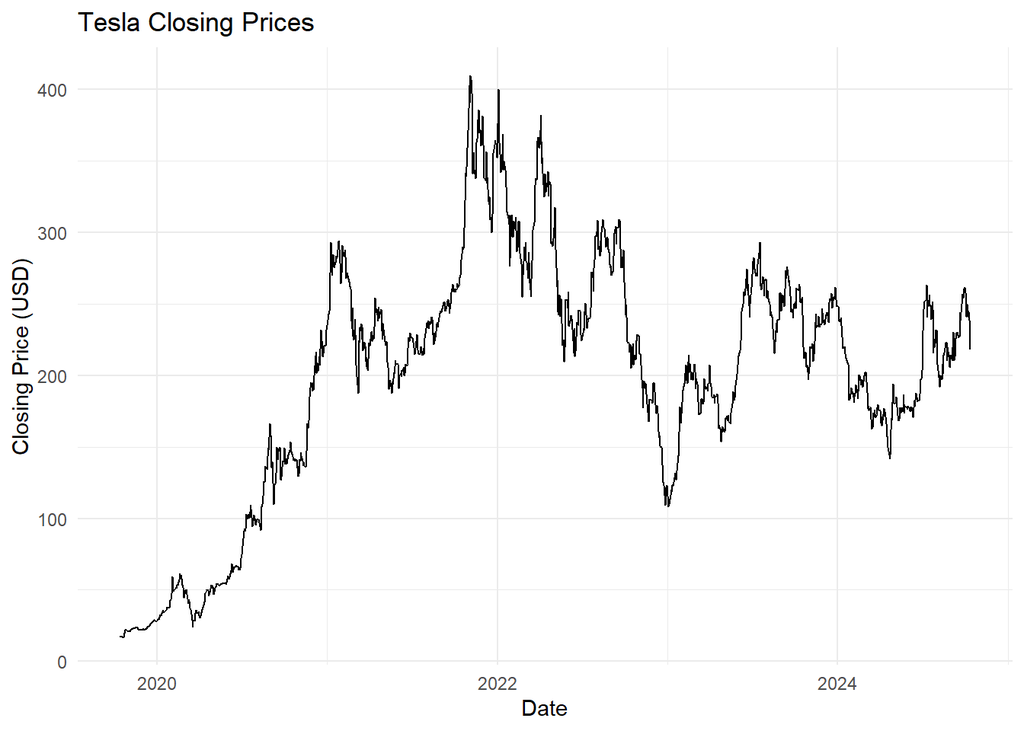

```r
# Plot Tesla closing prices
ggplot(tesla_data, aes(x = Date, y = Close.Last)) +
  geom_line() +
  labs(title = "Tesla Closing Prices", x = "Date", y = "Closing Price (USD)") +
  theme_minimal()
```

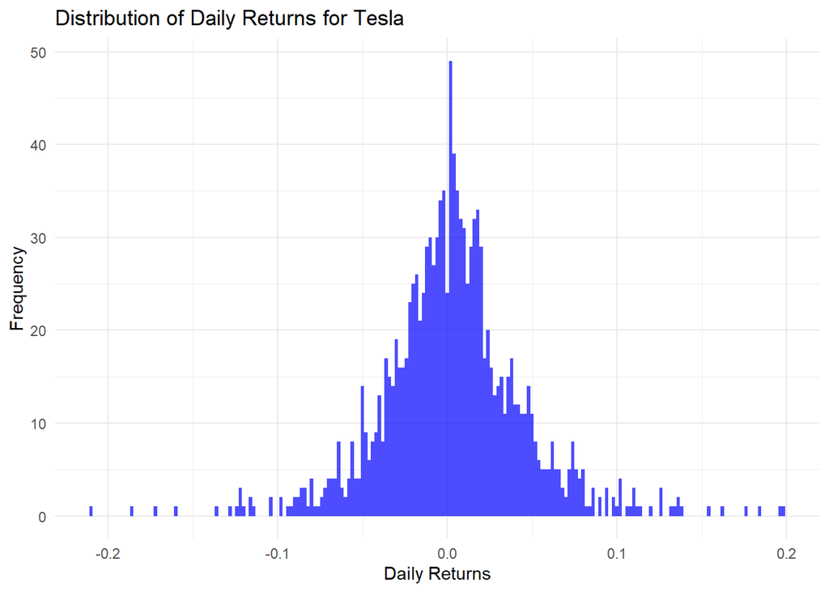

```r
# Compute daily returns
tesla_data <- tesla_data %>%
  mutate(Returns = (Close.Last - lag(Close.Last)) / lag(Close.Last))

# Plot the distribution of daily returns
ggplot(tesla_data, aes(x = Returns)) +
  geom_histogram(binwidth = 0.002, fill = "blue", alpha = 0.7) +
  labs(title = "Distribution of Daily Returns for Tesla", x = "Daily Returns", y = "Frequency") +
  theme_minimal()
```

```r
#View(tesla_data)
```

- The daily return is calculated as the percentage change between the closing price of the current day and the closing price of the previous day.

-The formula used is based on this concept:

Returns = (Close_Last - lag(Close_Last)) / lag(Close_Last)

This shows how much the stock’s closing price changed relative to the previous day.

- Tesla’s daily returns distribution shows a bell-shaped curve centered around 0, indicating that most daily returns are close to zero, with fewer extreme positive or negative returns.

# Tests for Stationarity

```r
# Augmented Dickey-Fuller (ADF) Test for stationarity
adf_test <- adf.test(na.omit(tesla_data$Close.Last))
print(adf_test)
```

```
##
##  Augmented Dickey-Fuller Test
##
## data:  na.omit(tesla_data$Close.Last)
## Dickey-Fuller = -2.3078, Lag order = 10, p-value = 0.448
## alternative hypothesis: stationary
```

```r
# KPSS Test for stationarity
kpss_test <- ur.kpss(na.omit(tesla_data$Close.Last))
summary(kpss_test)
```

```
##
## #######################
## # KPSS Unit Root Test #
## #######################
##
## Test is of type: mu with 7 lags.
##
## Value of test-statistic is: 5.0714
##
## Critical value for a significance level of:
##                 10pct  5pct 2.5pct  1pct
## critical values 0.347 0.463  0.574 0.739
```

The Augmented Dickey-Fuller (ADF) Test and KPSS Test are used to check stationarity, which is needed for modeling time series data. ADF tests for non-stationarity, while KPSS tests for stationarity.

- According to the ADF test, Tesla’ data appears to be non-stationary with p = 0.4 and greater than 0.05. The test statistic from the KPSS test = 5.07 and higher than all critical values meaning the data is again non-stationary.

# ACF and PACF plots

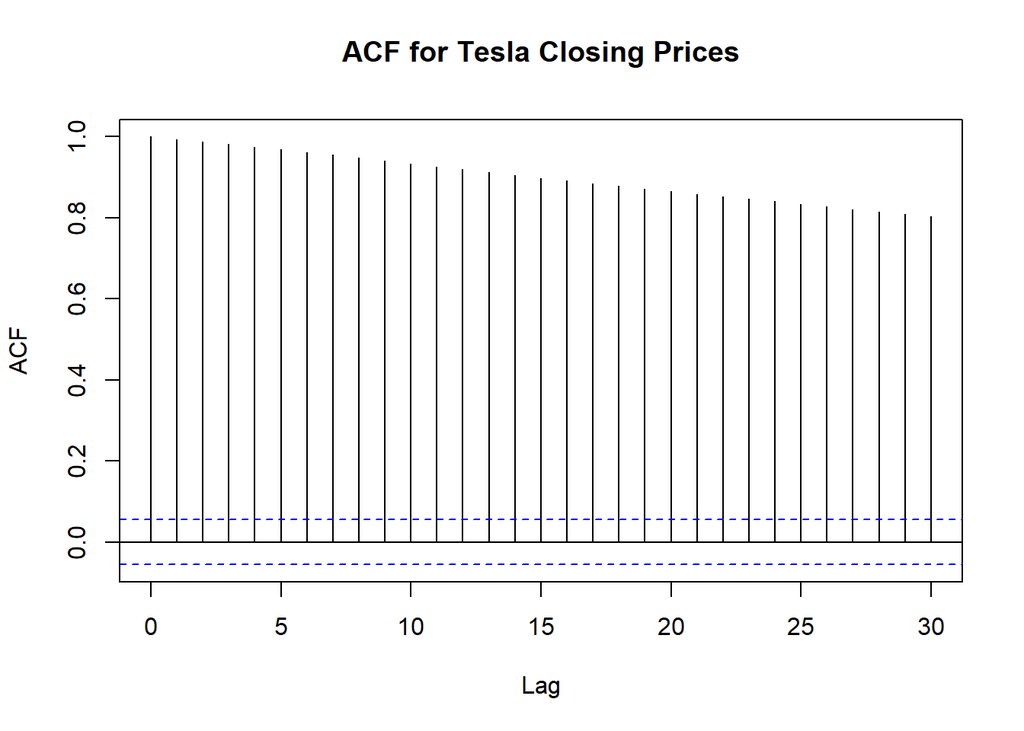

```r
# ACF (Autocorrelation Function) plot
acf(na.omit(tesla_data$Close.Last), main = "ACF for Tesla Closing Prices")
```

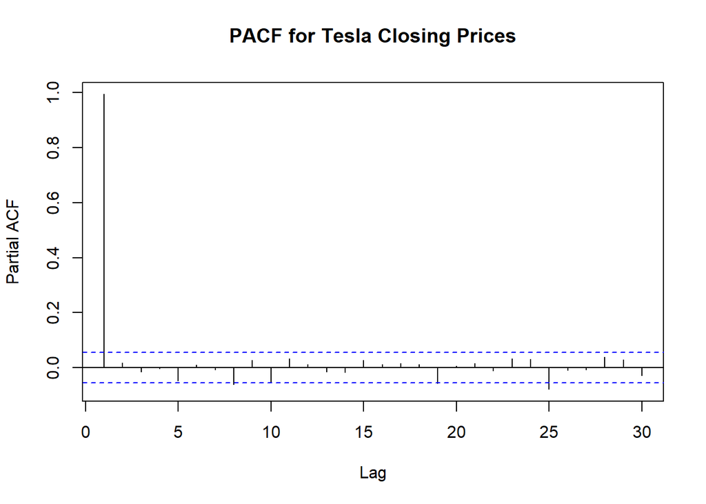

```r
# PACF (Partial Autocorrelation Function) plot
pacf(na.omit(tesla_data$Close.Last), main = "PACF for Tesla Closing Prices")
```

ACF and PACF plots help us identify significant lags for the ARIMA model, guiding the selection of AR (AutoRegressive) and MA (Moving Average) components. Tesla’s closing prices show significant autocorrelation which beings to decrease across multiple lags. This gradual decline in autocorrelation means that the time series is non-stationary. This is provides further support for the Dickey-Fuller Test. Hence, differencing might be necessary.

PACF plot shows a significant spike at lag 1 followed by values near zero for subsequent lags, indicating that only the most recent lag (lag 1) has a strong linear relationship with the current value, while higher-order lags do not contribute much to the current value.

# ARIMA Model Hyperparameter Tuning via Grid Search

```r
# Hyperparameter Tuning via Grid Search
p <- d <- q <- 0:2
best_aic <- Inf
best_order <- c(0,0,0)
for (i in p) {
  for (j in d) {
    for (k in q) {
      try({
        model <- arima(tesla_data$Close.Last, order = c(i, j, k))
        aic_val <- AIC(model)
        if (aic_val < best_aic) {
          best_aic <- aic_val
          best_order <- c(i, j, k)
        }
      }, silent = TRUE)
    }
  }
}
cat("Best ARIMA Order:", best_order, "with AIC:", best_aic, "\n")
```

```
## Best ARIMA Order: 0 1 0 with AIC: 8857.531
```

```r
# Fit the selected ARIMA model
arima_model <- arima(tesla_data$Close.Last, order = best_order)
summary(arima_model)
```

```
##
## Call:
## arima(x = tesla_data$Close.Last, order = best_order)
##
##
## sigma^2 estimated as 67.16:  log likelihood = -4427.77,  aic = 8857.53
##
## Training set error measures:
##                     ME     RMSE      MAE       MPE     MAPE      MASE
## Training set 0.1595282 8.191936 5.635379 0.1158517 2.955169 0.9992075
##                     ACF1
## Training set -0.03393234
```

We’ve added a loop that performs a grid search over different (p, d, q) combinations to find the best ARIMA model by minimizing the AIC (Akaike Information Criterion). Alternately for more robustness checks we will use Auto ARIMA for model selection in the next section.

The best AIC in this case is 8857.531

# Auto ARIMA for automatic model selection

```r
# Auto ARIMA for automatic model selection
auto_model <- auto.arima(tesla_data$Close.Last)
summary(auto_model)
```

```
## Series: tesla_data$Close.Last
## ARIMA(0,1,0)
##
## sigma^2 = 67.16:  log likelihood = -4427.77
## AIC=8857.53   AICc=8857.53   BIC=8862.67
##
## Training set error measures:
##                     ME     RMSE      MAE       MPE     MAPE      MASE
## Training set 0.1595282 8.191936 5.635379 0.1158517 2.955169 0.9992075
##                     ACF1
## Training set -0.03393234
```

It is observed that both Grid Search and Auto ARIMA gives the same ARIMA (0,1,0) output which confirms the robustness of our models that the best (p,q,d) parameters are being selected for this project.

# Residual diagnostics

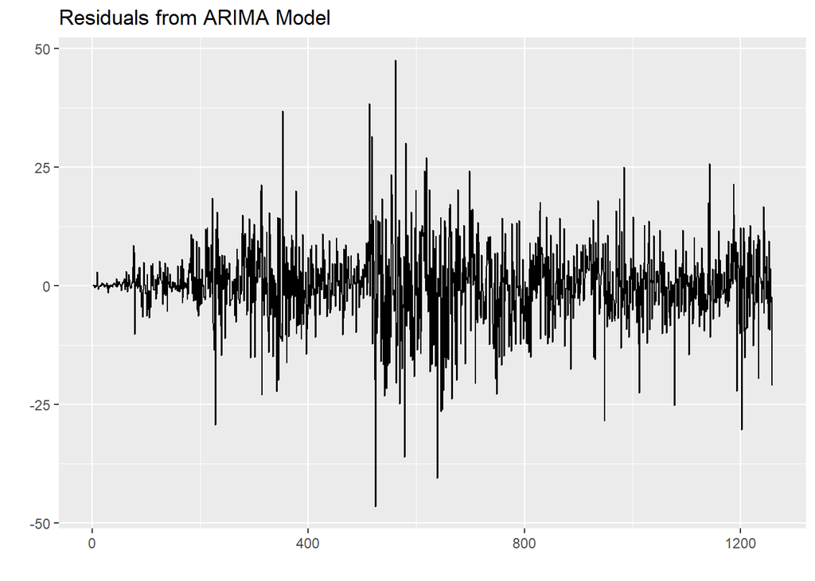

```r
# Residual diagnostics to check for autocorrelation using the ACF of residuals and the Ljung-Box test.
residuals <- residuals(arima_model)
autoplot(residuals) + ggtitle("Residuals from ARIMA Model")
```

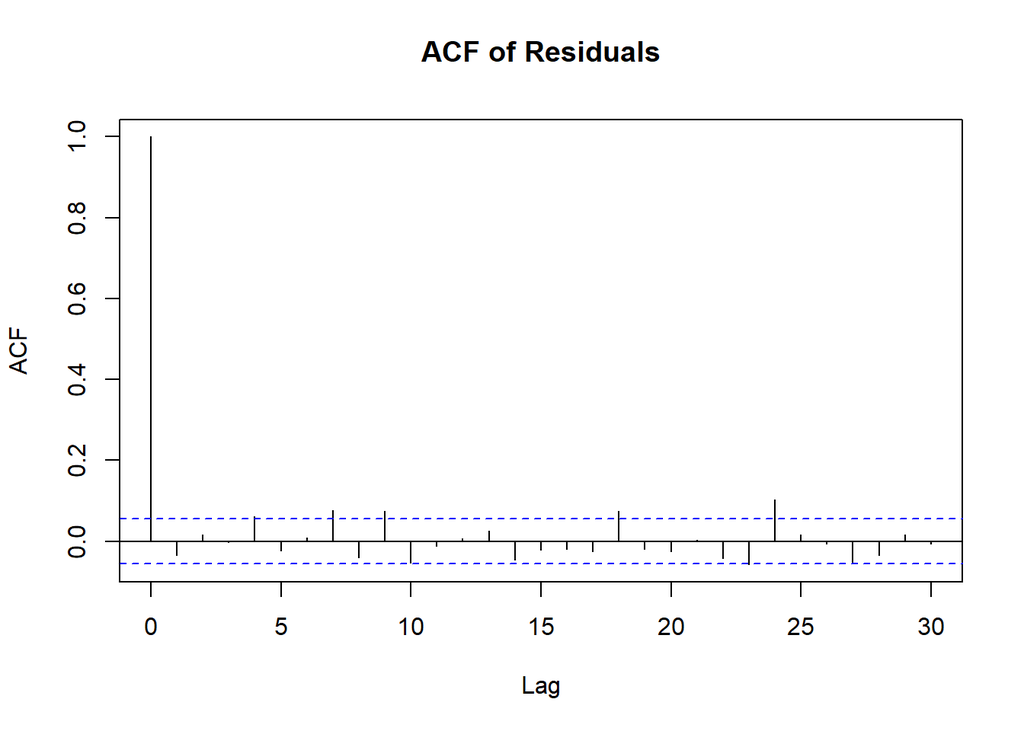

```r
acf(residuals, main = "ACF of Residuals")
```

```r
Box.test(residuals, lag = 10, type = "Ljung-Box")
```

```
##
##  Box-Ljung test
##
## data:  residuals
## X-squared = 27.631, df = 10, p-value = 0.002068
```

From the residual plot that shows the ARIMA model predicting Tesla’s stock price, the residuals appear to fluctuate around zero without any obvious pattern. This is a good sign for the model as it suggests that the errors (residuals) are not systematic, which is one of the key criteria for evaluating a time series model.

# Forecasting

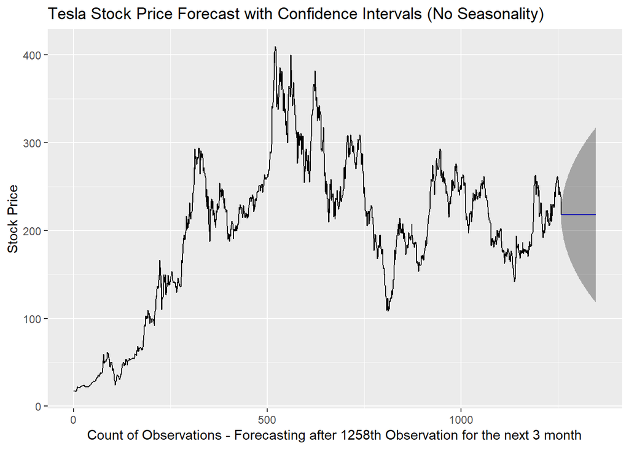

```r
# Forecasting with confidence intervals (Assuming no seasonality)
forecast_values <- forecast(arima_model, h = 90)
autoplot(forecast_values) +
  ggtitle("Tesla Stock Price Forecast with Confidence Intervals (No Seasonality)") +
  labs(y = "Stock Price", x = "Count of Observations - Forecasting after 1258th Observation for the next 3 month")
```

```r
# Calculate 95% CI for forecasted values

ci_95 <- data.frame(Lower_95 = forecast_values$lower[,2],
                    Upper_95 = forecast_values$upper[,2])

head(ci_95)
```

|  | Lower_95 | Upper_95 |
| --- | --- | --- |
| 1 | 201.7377 | 233.8623 |
| 2 | 195.0845 | 240.5155 |
| 3 | 189.9793 | 245.6207 |
| 4 | 185.6754 | 249.9246 |
| 5 | 181.8836 | 253.7164 |
| 6 | 178.4556 | 257.1444 |

# Seasonal ARIMA Model (SARIMAX)

```r
# Seasonal ARIMA Model (SARIMAX)
sarima_model <- arima(tesla_data$Close.Last, order = c(1,1,1), seasonal = list(order = c(1,1,1), period = 5))
summary(sarima_model)
```

```
##
## Call:
## arima(x = tesla_data$Close.Last, order = c(1, 1, 1), seasonal = list(order = c(1,
##     1, 1), period = 5))
##
## Coefficients:
##           ar1     ma1     sar1     sma1
##       -0.5773  0.5434  -0.0175  -1.0000
## s.e.   0.2517  0.2578   0.0286   0.0139
##
## sigma^2 estimated as 67.21:  log likelihood = -4424.49,  aic = 8858.97
##
## Training set error measures:
##                      ME     RMSE      MAE        MPE    MAPE      MASE
## Training set -0.1881782 8.178346 5.616177 -0.1226675 2.94387 0.9958028
##                     ACF1
## Training set 0.001600308
```

# Holt-Winters Exponential Smoothing

```r
# Convert the 'Close.Last' column to a time series object without seasonal frequency
tesla_ts <- ts(tesla_data$Close.Last, frequency = 5)  # Assuming 5 trading days per week

# Holt-Winters with weekly seasonality (assuming 5 trading days per week)
hw_model <- HoltWinters(tesla_ts, seasonal = "additive")  # Try 'additive' or 'multiplicative'
summary(hw_model)
```

```
##              Length Class  Mode
## fitted       5012   mts    numeric
## x            1258   ts     numeric
## alpha           1   -none- numeric
## beta            1   -none- numeric
## gamma           1   -none- numeric
## coefficients    7   -none- numeric
## seasonal        1   -none- character
## SSE             1   -none- numeric
## call            3   -none- call
```

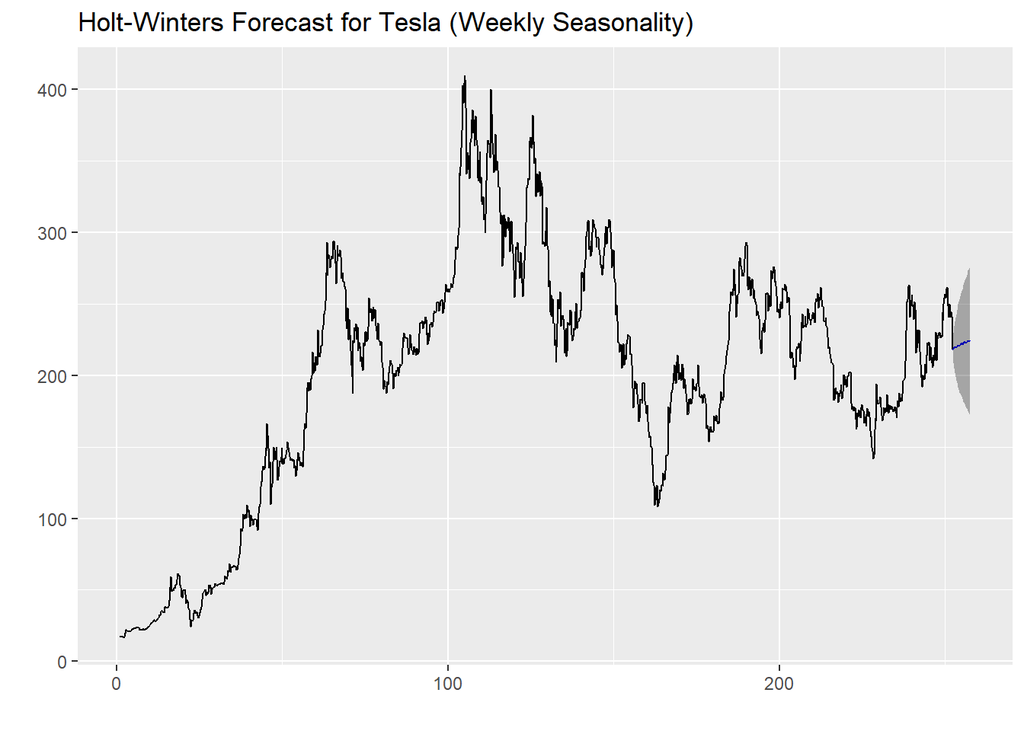

```r
# Forecasting the next 90 days
hw_forecast <- forecast(hw_model, h = 26)
autoplot(hw_forecast) +
  ggtitle("Holt-Winters Forecast for Tesla (Weekly Seasonality)")
```

# Time Series Cross-Validation

```r
# Cross Validation for Time Series with RMSE
n <- length(tesla_data$Close.Last)
folds <- cut(seq(1, n), breaks = 5, labels = FALSE)
rmse_values <- c()  # Vector to store RMSE values

for (i in 1:5) {
  # Create training and test sets for each fold
  test_indices <- which(folds == i, arr.ind = TRUE)
  train_data <- tesla_data$Close.Last[-test_indices]
  test_data <- tesla_data$Close.Last[test_indices]

  # Fit ARIMA model on the training data
  arima_fit <- arima(train_data, order = c(1,1,1))

  # Forecast on the test set
  forecasted <- forecast(arima_fit, h = length(test_data))

  # Calculate RMSE
  rmse <- sqrt(mean((forecasted$mean - test_data)^2))
  rmse_values <- c(rmse_values, rmse)  # Store the RMSE value for each fold

  # Output RMSE for each fold
  cat("Fold", i, "RMSE:", rmse, "\n")
}
```

```
## Fold 1 RMSE: 160.3011
## Fold 2 RMSE: 37.77295
## Fold 3 RMSE: 93.09777
## Fold 4 RMSE: 46.04946
## Fold 5 RMSE: 62.15723
```

```r
# Display all RMSE values across folds
rmse_values
```

```
## [1] 160.30112  37.77295  93.09777  46.04946  62.15723
```

The RMSE values are significantly higher here than the 8.191 and 8.17 values we got through Grid Search, Auto ARIMA, and seasonal ARIMA modeling. This can be due to the initial models being fitted on the entire dataset and then evaluated on the same data (or a portion of the data close to the training set). In contrast, during CV, the model is trained on smaller subsets of the data and tested on unseen data which naturally results in a higher RMSE because the model is not as well-tuned for the smaller training set and subsequent subsets.

# Granger Causality Test

```r
# Granger Causality Test (for causality)
granger_test <- grangertest(Close.Last ~ Returns, order = 5, data = tesla_data)
print(granger_test)
```

```
## Granger causality test
##
## Model 1: Close.Last ~ Lags(Close.Last, 1:5) + Lags(Returns, 1:5)
## Model 2: Close.Last ~ Lags(Close.Last, 1:5)
##   Res.Df Df      F Pr(>F)
## 1   1241
## 2   1246 -5 0.4427 0.8188
```

```r
granger_test_02 <- grangertest(Close.Last ~ Returns, order = 365, data = tesla_data)
print(granger_test_02)
```

```
## Granger causality test
##
## Model 1: Close.Last ~ Lags(Close.Last, 1:365) + Lags(Returns, 1:365)
## Model 2: Close.Last ~ Lags(Close.Last, 1:365)
##   Res.Df   Df      F Pr(>F)
## 1    161
## 2    526 -365 0.7744 0.9747
```

The Granger Causality Test determines whether one time series (e.g., returns) can predict another time series (e.g., closing price). The test helps analyze the causal relationships between different variables. The test shows that Returns do not Granger-cause Closing price since p-value = 0.81 > 0.05. At a 5-lag order, the past values of Returns do not have significant predictive power on Tesla’s closing prices.

The Grander Causality Test was then expanded to include a full year at 365-lag order. This however produced a higher value at .97 which is greater than .05. This indicates that even a year of Tesla’s stock data does not have significant predictive power on Tesla’s closing prices.

Additionally, these high p-values indicate that the probability of observing a result as extreme as these given that the null hypothesis is true is very high.